# Chapter 8 – Linear Discriminant Analysis (LDA)

### Applications of LDA

1. **Face Recognition**  
   In computer vision, LDA is widely used for face recognition. Each face is represented by a large number of pixel values. LDA is applied to reduce the dimensionality of these features, making the classification process more manageable. The resulting new dimensions are linear combinations of pixel values, called *Fisher’s faces*, which form templates used for classification.
2. **Medical Diagnosis**  
   LDA is used to classify patients' disease states (e.g., mild, moderate, or severe) based on various medical parameters and ongoing treatments. This helps doctors adjust their treatment plans based on the severity of the condition.
3. **Customer Identification**  
   In marketing, LDA can be used to identify customers who are most likely to purchase a specific product. By conducting surveys, features describing customer preferences are collected, and LDA is applied to select the key factors that distinguish potential buyers, aiding targeted marketing strategies.

```
Call:
qda(Species ~ ., data = iris)

Prior probabilities of groups:
    setosa versicolor  virginica
 0.3333333  0.3333333  0.3333333

Group means:
           Sepal.Length Sepal.Width Petal.Length Petal.Width
setosa            5.006       3.428        1.462       0.246
versicolor        5.936       2.770        4.260       1.326
virginica         6.588       2.974        5.552       2.026
```

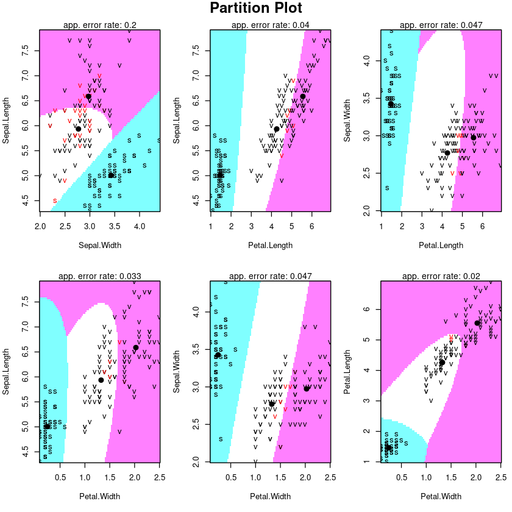

```r
# Quardratic discriminant analysis
# For QDA, the assumption of equal covarince matrix over all classes is not assumed.
fit.q = qda(Species~., iris)
fit.q

# Partition plot with Linear Discriminant Analysis Model in a two dimensional space
# Exploratory Graph for LDA
partimat(Species~., data=iris, method="qda")
```

# Example: A hospital uses Linear Discriminant Analysis to classify patients as Diabetic or Non-Diabetic based on age, glucose level, BMI, and blood pressure.

Pima.tr contains medical and demographic measurements from adult female patients of Pima Indian heritage. The goal is to predict whether a patient has diabetes based on clinical predictors.

| Variable | Description |
| --- | --- |
| `npreg` | Number of pregnancies |
| `glu` | Plasma glucose concentration (2-hours post glucose challenge) |
| `bp` | Diastolic blood pressure (mm Hg) |
| `skin` | Triceps skin fold thickness (mm) |
| `bmi` | Body mass index (weight/height²) |
| `ped` | Diabetes pedigree function (family history index) |
| `age` | Age in years |
| `type` | **Outcome**: `"Yes"` (diabetes) or `"No"` (no diabetes) |

```r
library(MASS)

data = Pima.tr
```